# COMPSCIX 415.2 Homework 7

Elizabeth Eldridge

March 12, 2019

## Exercise 1:

Load the train.csv dataset into R. How many observations and columns are there?

- There are 1,460 rows and 81 columns in the train.csv dataset.

```r
traindata <- read_csv('I:/train.csv')
head(traindata)
```

```
## # A tibble: 6 x 81
##      Id MSSubClass MSZoning LotFrontage LotArea Street Alley LotShape
##   <dbl>      <dbl> <chr>          <dbl>   <dbl> <chr>  <chr> <chr>
## 1     1         60 RL                65    8450 Pave   <NA>  Reg
## 2     2         20 RL                80    9600 Pave   <NA>  Reg
## 3     3         60 RL                68   11250 Pave   <NA>  IR1
## 4     4         70 RL                60    9550 Pave   <NA>  IR1
## 5     5         60 RL                84   14260 Pave   <NA>  IR1
## 6     6         50 RL                85   14115 Pave   <NA>  IR1
## # ... with 73 more variables: LandContour <chr>, Utilities <chr>,
## #   LotConfig <chr>, LandSlope <chr>, Neighborhood <chr>,
## #   Condition1 <chr>, Condition2 <chr>, BldgType <chr>, HouseStyle <chr>,
## #   OverallQual <dbl>, OverallCond <dbl>, YearBuilt <dbl>,
## #   YearRemodAdd <dbl>, RoofStyle <chr>, RoofMatl <chr>,
## #   Exterior1st <chr>, Exterior2nd <chr>, MasVnrType <chr>,
## #   MasVnrArea <dbl>, ExterQual <chr>, ExterCond <chr>, Foundation <chr>,
## #   BsmtQual <chr>, BsmtCond <chr>, BsmtExposure <chr>,
## #   BsmtFinType1 <chr>, BsmtFinSF1 <dbl>, BsmtFinType2 <chr>,
## #   BsmtFinSF2 <dbl>, BsmtUnfSF <dbl>, TotalBsmtSF <dbl>, Heating <chr>,
## #   HeatingQC <chr>, CentralAir <chr>, Electrical <chr>, `1stFlrSF` <dbl>,
## #   `2ndFlrSF` <dbl>, LowQualFinSF <dbl>, GrLivArea <dbl>,
## #   BsmtFullBath <dbl>, BsmtHalfBath <dbl>, FullBath <dbl>,
## #   HalfBath <dbl>, BedroomAbvGr <dbl>, KitchenAbvGr <dbl>,
## #   KitchenQual <chr>, TotRmsAbvGrd <dbl>, Functional <chr>,
## #   Fireplaces <dbl>, FireplaceQu <chr>, GarageType <chr>,
## #   GarageYrBlt <dbl>, GarageFinish <chr>, GarageCars <dbl>,
## #   GarageArea <dbl>, GarageQual <chr>, GarageCond <chr>,
## #   PavedDrive <chr>, WoodDeckSF <dbl>, OpenPorchSF <dbl>,
## #   EnclosedPorch <dbl>, `3SsnPorch` <dbl>, ScreenPorch <dbl>,
## #   PoolArea <dbl>, PoolQC <chr>, Fence <chr>, MiscFeature <chr>,
## #   MiscVal <dbl>, MoSold <dbl>, YrSold <dbl>, SaleType <chr>,
## #   SaleCondition <chr>, SalePrice <dbl>
```

```r
nrow(traindata)
```

```
## [1] 1460
```

```r
ncol(traindata)
```

```
## [1] 81
```

## Exercise 2:

Normally at this point you would spend a few days on EDA, but for this homework we will do some very basic EDA and get right to fitting some linear regression models. Our target will be SalePrice.

Visualize the distribution of SalePrice. Visualize the covariation between SalePrice and Neighborhood. Visualize the covariation between SalePrice and OverallQual.

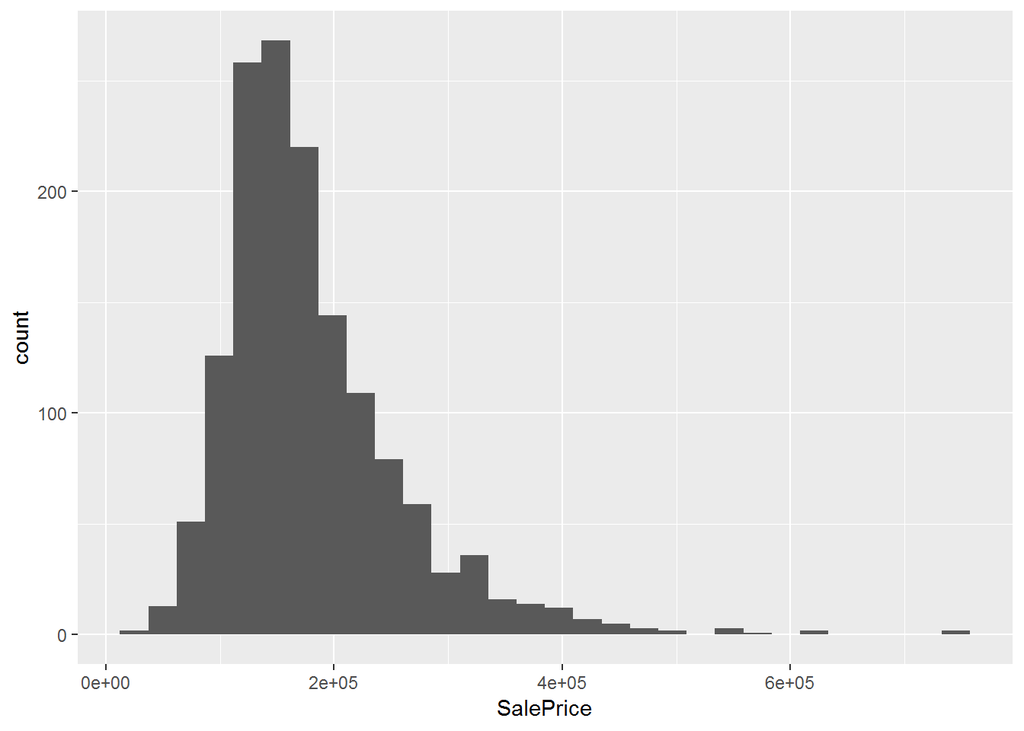

```r
#names(traindata)

#Visualize the distribution of SalePrice
(g1<-ggplot(traindata, aes(SalePrice)) + geom_histogram())
```

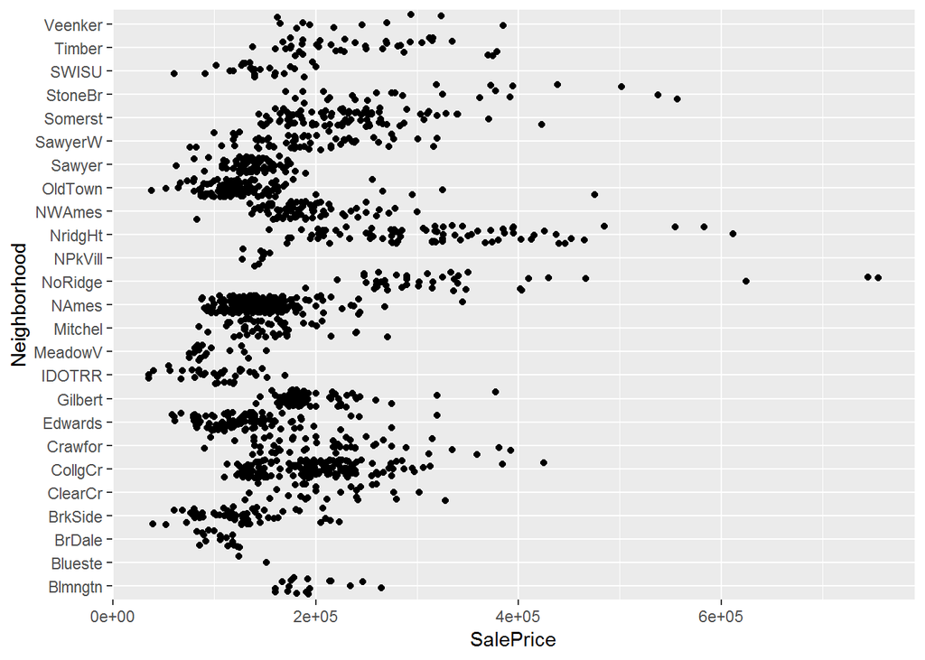

```r
#Visualize the covariation between SalePrice and Neighborhood
ggplot(traindata, aes(SalePrice, Neighborhood) ) +
  geom_jitter()
```

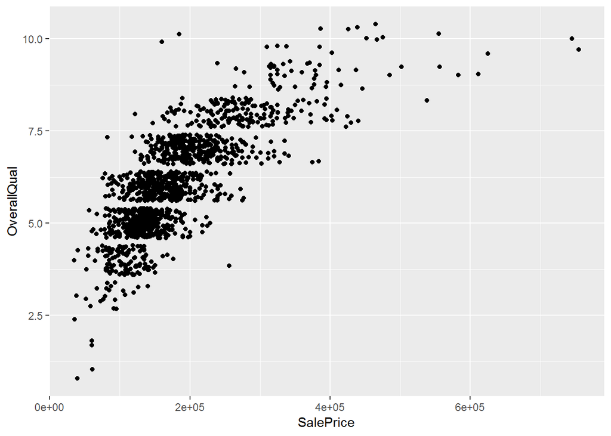

```r
#Visualize the covariation between SalePrice and OverallQual
ggplot(traindata, aes(SalePrice, OverallQual) ) +
  geom_jitter()
```